# churn

```python
import pandas as pd
import numpy as np
import matplotlib.pyplot as plt
from sklearn.preprocessing import StandardScaler
from sklearn.preprocessing import OneHotEncoder
from sklearn.linear_model import LogisticRegressionCV
from sklearn.ensemble import RandomForestClassifier
from sklearn.ensemble import GradientBoostingClassifier
import seaborn as sns
from scipy import stats
from IPython import display

np.random.seed(72023)
pd.set_option('display.max_columns', None)
```

```python
csv_churn = pd.read_csv('churn_clean.csv')

csv_churn
```

|  | CaseOrder | Customer_id | Interaction | UID | City | State | County | Zip | Lat | Lng | Population | Area | TimeZone | Job | Children | Age | Income | Marital | Gender | Churn | Outage_sec_perweek | Email | Contacts | Yearly_equip_failure | Techie | Contract | Port_modem | Tablet | InternetService | … |
| --- | --- | --- | --- | --- | --- | --- | --- | --- | --- | --- | --- | --- | --- | --- | --- | --- | --- | --- | --- | --- | --- | --- | --- | --- | --- | --- | --- | --- | --- | --- |
| 0 | 1 | K409198 | aa90260b-4141-4a24-8e36-b04ce1f4f77b | e885b299883d4f9fb18e39c75155d990 | Point Baker | AK | Prince of Wales-Hyder | 99927 | 56.25100 | -133.37571 | 38 | Urban | America/Sitka | Environmental health practitioner | 0 | 68 | 28561.99 | Widowed | Male | No | 7.978323 | 10 | 0 | 1 | No | One year | Yes | Yes | Fiber Optic | … |
| 1 | 2 | S120509 | fb76459f-c047-4a9d-8af9-e0f7d4ac2524 | f2de8bef964785f41a2959829830fb8a | West Branch | MI | Ogemaw | 48661 | 44.32893 | -84.24080 | 10446 | Urban | America/Detroit | Programmer, multimedia | 1 | 27 | 21704.77 | Married | Female | Yes | 11.699080 | 12 | 0 | 1 | Yes | Month-to-month | No | Yes | Fiber Optic | … |
| 2 | 3 | K191035 | 344d114c-3736-4be5-98f7-c72c281e2d35 | f1784cfa9f6d92ae816197eb175d3c71 | Yamhill | OR | Yamhill | 97148 | 45.35589 | -123.24657 | 3735 | Urban | America/Los_Angeles | Chief Financial Officer | 4 | 50 | 9609.57 | Widowed | Female | No | 10.752800 | 9 | 0 | 1 | Yes | Two Year | Yes | No | DSL | … |
| 3 | 4 | D90850 | abfa2b40-2d43-4994-b15a-989b8c79e311 | dc8a365077241bb5cd5ccd305136b05e | Del Mar | CA | San Diego | 92014 | 32.96687 | -117.24798 | 13863 | Suburban | America/Los_Angeles | Solicitor | 1 | 48 | 18925.23 | Married | Male | No | 14.913540 | 15 | 2 | 0 | Yes | Two Year | No | No | DSL | … |
| 4 | 5 | K662701 | 68a861fd-0d20-4e51-a587-8a90407ee574 | aabb64a116e83fdc4befc1fbab1663f9 | Needville | TX | Fort Bend | 77461 | 29.38012 | -95.80673 | 11352 | Suburban | America/Chicago | Medical illustrator | 0 | 83 | 40074.19 | Separated | Male | Yes | 8.147417 | 16 | 2 | 1 | No | Month-to-month | Yes | No | Fiber Optic | … |
| ... | ... | ... | ... | ... | ... | ... | ... | ... | ... | ... | ... | ... | ... | ... | ... | ... | ... | ... | ... | ... | ... | ... | ... | ... | ... | ... | ... | ... | ... | … |
| 9995 | 9996 | M324793 | 45deb5a2-ae04-4518-bf0b-c82db8dbe4a4 | 9499fb4de537af195d16d046b79fd20a | Mount Holly | VT | Rutland | 5758 | 43.43391 | -72.78734 | 640 | Rural | America/New_York | Sport and exercise psychologist | 3 | 23 | 55723.74 | Married | Male | No | 9.415935 | 12 | 2 | 0 | No | Month-to-month | Yes | Yes | DSL | … |
| 9996 | 9997 | D861732 | 6e96b921-0c09-4993-bbda-a1ac6411061a | c09a841117fa81b5c8e19afec2760104 | Clarksville | TN | Montgomery | 37042 | 36.56907 | -87.41694 | 77168 | Rural | America/Chicago | Consulting civil engineer | 4 | 48 | 34129.34 | Divorced | Male | No | 6.740547 | 15 | 2 | 0 | No | Two Year | No | No | Fiber Optic | … |
| 9997 | 9998 | I243405 | e8307ddf-9a01-4fff-bc59-4742e03fd24f | 9c41f212d1e04dca84445019bbc9b41c | Mobeetie | TX | Wheeler | 79061 | 35.52039 | -100.44180 | 406 | Rural | America/Chicago | IT technical support officer | 1 | 48 | 45983.43 | Never Married | Female | No | 6.590911 | 10 | 0 | 0 | No | Month-to-month | No | No | Fiber Optic | … |
| 9998 | 9999 | I641617 | 3775ccfc-0052-4107-81ae-9657f81ecdf3 | 3e1f269b40c235a1038863ecf6b7a0df | Carrollton | GA | Carroll | 30117 | 33.58016 | -85.13241 | 35575 | Urban | America/New_York | Water engineer | 1 | 39 | 16667.58 | Separated | Male | No | 12.071910 | 14 | 1 | 0 | No | Two Year | No | Yes | Fiber Optic | … |
| 9999 | 10000 | T38070 | 9de5fb6e-bd33-4995-aec8-f01d0172a499 | 0ea683a03a3cd544aefe8388aab16176 | Clarkesville | GA | Habersham | 30523 | 34.70783 | -83.53648 | 12230 | Urban | America/New_York | Personal assistant | 1 | 28 | 9020.92 | Never Married | Male | No | 11.754720 | 17 | 1 | 0 | No | Month-to-month | Yes | No | Fiber Optic | … |

10000 rows × 50 columns

To create the initial dataframe, I removed columns relating to customer ID, survey responses, and other miscellaneous information that is better captured in different variables; for example, latitude and longitude are not very helpful if the customer's state of residence is already given. I felt that the variables I omitted did not offer much benefit and could reasonably be pruned to better the results of the analysis.

The output below showcases which variables were included for the analysis. It also demonstrates that the dataset is complete, with no missing values. A further description of each variable can be found in the attached data dictionary file.

```python
df = csv_churn.copy().loc[:, ~csv_churn.columns.isin(['Customer_id', 'Interaction', 'UID',
                                     'County', 'Zip', 'Lat', 'Lng', 'Population',
                                     'TimeZone', 'Job', 'Item1', 'Item2',
                                     'Item3', 'Item4', 'Item5', 'Item6',
                                     'Item7', 'Item8', 'CaseOrder', 'City'])]

df.info()
```

```
<class 'pandas.core.frame.DataFrame'>
RangeIndex: 10000 entries, 0 to 9999
Data columns (total 30 columns):
 #   Column                Non-Null Count  Dtype
---  ------                --------------  -----
 0   State                 10000 non-null  object
 1   Area                  10000 non-null  object
 2   Children              10000 non-null  int64
 3   Age                   10000 non-null  int64
 4   Income                10000 non-null  float64
 5   Marital               10000 non-null  object
 6   Gender                10000 non-null  object
 7   Churn                 10000 non-null  object
 8   Outage_sec_perweek    10000 non-null  float64
 9   Email                 10000 non-null  int64
```

[output cut: 22 more lines]

To prepare the data for further analysis, I standardized all of the quantitative variables, converted the yes/no values to 1s and 0s respectively, and one hot encoded the other categorical variables.

```python
df_quant = df.select_dtypes(include=('float64', 'int64'))
df_cat = df[['State', 'Area', 'Marital', 'Gender', 'Contract',
                'InternetService', 'PaymentMethod']]
df_y_n = df.loc[:, ~df.columns.isin(df_quant + df_cat)]
scaler = StandardScaler()
scaled_quant = pd.DataFrame(scaler.fit_transform(df_quant),
                            columns=df_quant.columns)
ohe = OneHotEncoder(sparse_output=False)
encoded_cat = pd.DataFrame(ohe.fit_transform(df_cat),
                           columns=ohe.get_feature_names_out(df_cat.columns))
df_processed = pd.concat([scaled_quant, encoded_cat], axis=1)
for col in df_y_n:
    df_processed[col] = df_y_n[col].map({'Yes':1, 'No':0})

df_processed
```

|  | Children | Age | Income | Outage_sec_perweek | Email | Contacts | Yearly_equip_failure | Tenure | MonthlyCharge | Bandwidth_GB_Year | State_AK | State_AL | State_AR | State_AZ | State_CA | State_CO | State_CT | State_DC | State_DE | State_FL | State_GA | State_HI | State_IA | State_ID | State_IL | State_IN | State_KS | State_KY | State_LA | … |
| --- | --- | --- | --- | --- | --- | --- | --- | --- | --- | --- | --- | --- | --- | --- | --- | --- | --- | --- | --- | --- | --- | --- | --- | --- | --- | --- | --- | --- | --- | --- |
| 0 | -0.972338 | 0.720925 | -0.398778 | -0.679978 | -0.666282 | -1.005852 | 0.946658 | -1.048746 | -0.003943 | -1.138487 | 1.0 | 0.0 | 0.0 | 0.0 | 0.0 | 0.0 | 0.0 | 0.0 | 0.0 | 0.0 | 0.0 | 0.0 | 0.0 | 0.0 | 0.0 | 0.0 | 0.0 | 0.0 | 0.0 | … |
| 1 | -0.506592 | -1.259957 | -0.641954 | 0.570331 | -0.005288 | -1.005852 | 0.946658 | -1.262001 | 1.630326 | -1.185876 | 0.0 | 0.0 | 0.0 | 0.0 | 0.0 | 0.0 | 0.0 | 0.0 | 0.0 | 0.0 | 0.0 | 0.0 | 0.0 | 0.0 | 0.0 | 0.0 | 0.0 | 0.0 | 0.0 | … |
| 2 | 0.890646 | -0.148730 | -1.070885 | 0.252347 | -0.996779 | -1.005852 | 0.946658 | -0.709940 | -0.295225 | -0.612138 | 0.0 | 0.0 | 0.0 | 0.0 | 0.0 | 0.0 | 0.0 | 0.0 | 0.0 | 0.0 | 0.0 | 0.0 | 0.0 | 0.0 | 0.0 | 0.0 | 0.0 | 0.0 | 0.0 | … |
| 3 | -0.506592 | -0.245359 | -0.740525 | 1.650506 | 0.986203 | 1.017588 | -0.625864 | -0.659524 | -1.226521 | -0.561857 | 0.0 | 0.0 | 0.0 | 0.0 | 1.0 | 0.0 | 0.0 | 0.0 | 0.0 | 0.0 | 0.0 | 0.0 | 0.0 | 0.0 | 0.0 | 0.0 | 0.0 | 0.0 | 0.0 | … |
| 4 | -0.972338 | 1.445638 | 0.009478 | -0.623156 | 1.316700 | 1.017588 | 0.946658 | -1.242551 | -0.528086 | -1.428184 | 0.0 | 0.0 | 0.0 | 0.0 | 0.0 | 0.0 | 0.0 | 0.0 | 0.0 | 0.0 | 0.0 | 0.0 | 0.0 | 0.0 | 0.0 | 0.0 | 0.0 | 0.0 | 0.0 | … |
| ... | ... | ... | ... | ... | ... | ... | ... | ... | ... | ... | ... | ... | ... | ... | ... | ... | ... | ... | ... | ... | ... | ... | ... | ... | ... | ... | ... | ... | ... | … |
| 9995 | 0.424900 | -1.453214 | 0.564456 | -0.196888 | -0.005288 | 1.017588 | -0.625864 | 1.273401 | -0.294484 | 1.427298 | 0.0 | 0.0 | 0.0 | 0.0 | 0.0 | 0.0 | 0.0 | 0.0 | 0.0 | 0.0 | 0.0 | 0.0 | 0.0 | 0.0 | 0.0 | 0.0 | 0.0 | 0.0 | 0.0 | … |
| 9996 | 0.890646 | -0.245359 | -0.201344 | -1.095915 | 0.986203 | 1.017588 | -0.625864 | 1.002740 | 0.811726 | 1.054194 | 0.0 | 0.0 | 0.0 | 0.0 | 0.0 | 0.0 | 0.0 | 0.0 | 0.0 | 0.0 | 0.0 | 0.0 | 0.0 | 0.0 | 0.0 | 0.0 | 0.0 | 0.0 | 0.0 | … |
| 9997 | -0.506592 | -0.245359 | 0.219037 | -1.146198 | -0.666282 | -1.005852 | -0.625864 | 0.487513 | -0.061729 | 0.350984 | 0.0 | 0.0 | 0.0 | 0.0 | 0.0 | 0.0 | 0.0 | 0.0 | 0.0 | 0.0 | 0.0 | 0.0 | 0.0 | 0.0 | 0.0 | 0.0 | 0.0 | 0.0 | 0.0 | … |
| 9998 | -0.506592 | -0.680187 | -0.820588 | 0.695616 | 0.655706 | 0.005868 | -0.625864 | 1.383018 | 1.863005 | 1.407713 | 0.0 | 0.0 | 0.0 | 0.0 | 0.0 | 0.0 | 0.0 | 0.0 | 0.0 | 0.0 | 1.0 | 0.0 | 0.0 | 0.0 | 0.0 | 0.0 | 0.0 | 0.0 | 0.0 | … |
| 9999 | -0.506592 | -1.211643 | -1.091760 | 0.589028 | 1.647197 | 0.005868 | -0.625864 | 1.090120 | 1.044672 | 1.128163 | 0.0 | 0.0 | 0.0 | 0.0 | 0.0 | 0.0 | 0.0 | 0.0 | 0.0 | 0.0 | 1.0 | 0.0 | 0.0 | 0.0 | 0.0 | 0.0 | 0.0 | 0.0 | 0.0 | … |

10000 rows × 96 columns

1. Logistic lasso regression
2. Random forest classifier
3. Gradient boosting classifier

Despite train-test-splits being common for these methods, I find that it is not necessary for this instance. I am employing these as a means of feature selection and I am not trying to build a predictive model, so I will only be splitting the data by the dependent and independent variables for the modeling phase.

```python
X = df_processed.loc[:, df_processed.columns !='Churn']
y = df_processed['Churn']
```

```python
logR_lasso = LogisticRegressionCV(penalty='l1',
                                solver='liblinear')
logR_lasso.fit(X, y)
logR_lasso_coef = pd.DataFrame(logR_lasso.coef_, columns=X.columns).iloc[:, np.where(logR_lasso.coef_ != 0)[1]]
```

```python
rf = RandomForestClassifier()
rf.fit(X, y)
rf_feat_imp = pd.DataFrame(rf.feature_importances_.reshape(1,-1), columns=X.columns)
```

```python
gb = GradientBoostingClassifier()
gb.fit(X, y)
gb_feat_imp = pd.DataFrame(gb.feature_importances_.reshape(1,-1), columns=X.columns)
```

Once I had fit the models to the data, I extracted and sorted the coefficients from the logistic lasso regression, and the feature importance values from the random forest and gradient booosting classifiers. I then plot the top 15 values and visually examine where the high coefficient/feature importance grouping drops off for each method. Then I use their index to create a list of all of the highly correlated values from each model and then filter by which ones were significant in all three models.

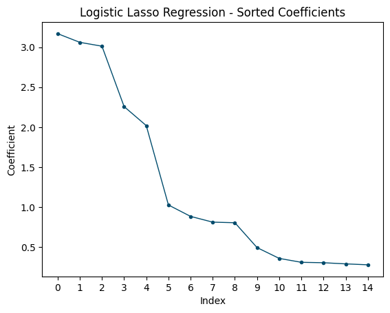

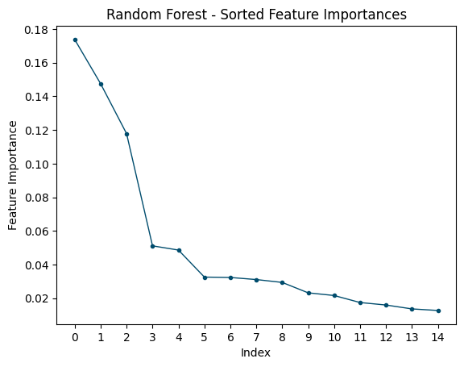

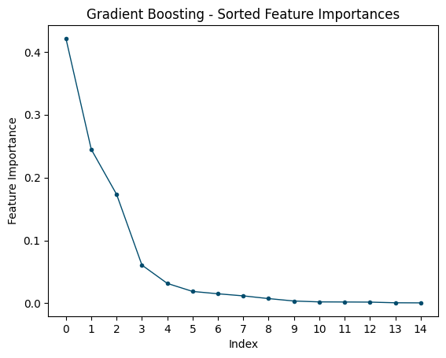

```python
logR_lasso_coef_abs_sorted = logR_lasso_coef.iloc[:, logR_lasso_coef.iloc[0].abs().argsort()[::-1]]
rf_feat_imp_sorted = rf_feat_imp.iloc[:, rf_feat_imp.iloc[0].argsort()[::-1]]
gb_feat_imp_sorted = gb_feat_imp.iloc[:, gb_feat_imp.iloc[0].argsort()[::-1]]

plt.plot(logR_lasso_coef_abs_sorted.iloc[:, 0:15].abs().values.flatten(),
         color='#004c6d', linewidth=1,
         marker='o', markersize=3)
plt.title("Logistic Lasso Regression - Sorted Coefficients")
plt.xlabel("Index")
plt.xticks(range(15))
plt.ylabel("Coefficient")
plt.show()

plt.plot(rf_feat_imp_sorted.iloc[:, 0:15].values.flatten(),
         color='#004c6d', linewidth=1,
         marker='o', markersize=3)
plt.title("Random Forest - Sorted Feature Importances")
plt.xlabel("Index")
plt.xticks(range(15))
plt.ylabel("Feature Importance")
plt.show()

plt.plot(gb_feat_imp_sorted.iloc[:, 0:15].values.flatten(),
         color='#004c6d', linewidth=1,
         marker='o', markersize=3)
plt.title("Gradient Boosting - Sorted Feature Importances")
plt.xlabel("Index")
plt.xticks(range(15))
plt.ylabel("Feature Importance")
plt.show()
```

The logistic lasso regression had five variables in the highly correlated grouping, while the random forest and gradient boosting classifiers only had three. Between the three models, there were only two variables that were significant in all three:

1. Tenure (Months)
2. Monthly Charge (US$)

Lastly, to confirm the results, I plotted churn (yes/no) as a function of tenure and monthly charge on a scatterplot, color-coded by churn. From the graph, we can see that newer customers with a higher monthly payment are correlated with higher churn rates.

```python
corr_variables = pd.Series(list(logR_lasso_coef_abs_sorted.iloc[:, 0:5].columns) +
                 list(rf_feat_imp_sorted.iloc[:, 0:3].columns) +
                 list(gb_feat_imp_sorted.iloc[:, 0:3].columns))
corr_variables = list(corr_variables[corr_variables.duplicated()].unique())

corr_variables
```

```
['Tenure', 'MonthlyCharge']
```

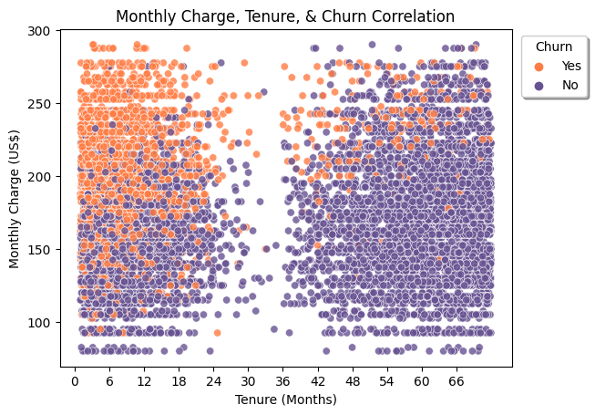

```python
my_palette = sns.color_palette(['#665191', '#ff7c43'])
sns.scatterplot(data=df,
                x='Tenure', y='MonthlyCharge',
                hue='Churn', alpha = 0.8,
                palette=my_palette)
plt.legend(bbox_to_anchor=(1.18, 1),
           loc='upper right',
           reverse=True,
           title="Churn",
           shadow=True)
plt.xlabel("Tenure (Months)")
plt.ylabel("Monthly Charge (US$)")
plt.xticks(range(0, 72, 6))
plt.title("Monthly Charge, Tenure, & Churn Correlation")
plt.show()
```

After looking at the graph up above, I became curious as to what the blue dots in the upper left corner had in common. It appears that the shorter a customer's tenure with this telecommunications company and the higher their monthly payment is, the more "at risk" they are for terminating their services. However, despite their high risk, many customers in this grouping still decide to stay. My next focus, and second analysis, became identifying the variables most associated with customer retention in high churn risk groups.

To move forward with this portion of the analysis, I decided to define a subset of customers in the dataset: the "At Risk" group. This is defined as having a sufficiently high monthly charge as well as being a sufficiently new customer. To determine where this cutoff would fall, I used logistic regression. The first graph shows the logistic regression probabilities for a customer's termination of services, the second shows where the logistic regression predicted termination of services. If the logistic regression predicted yes, they were assigned to the "At Risk" group. Both of the predictions and probabilities were stored as new values in the dataframe.

```python
X_subset = df.loc[:, df.columns.isin(['MonthlyCharge', 'Tenure'])]
```

```python
logR = LogisticRegressionCV()
logR.fit(X_subset, y)
df['atRisk_prob'] = logR.predict_proba(X_subset)[:,1]
df['atRisk'] = logR.predict(X_subset)
df['atRisk'] = df['atRisk'].map({1:'Yes', 0:'No'})

print(df.info())
df
```

```
<class 'pandas.core.frame.DataFrame'>
RangeIndex: 10000 entries, 0 to 9999
Data columns (total 32 columns):
 #   Column                Non-Null Count  Dtype
---  ------                --------------  -----
 0   State                 10000 non-null  object
 1   Area                  10000 non-null  object
 2   Children              10000 non-null  int64
 3   Age                   10000 non-null  int64
 4   Income                10000 non-null  float64
 5   Marital               10000 non-null  object
 6   Gender                10000 non-null  object
 7   Churn                 10000 non-null  object
 8   Outage_sec_perweek    10000 non-null  float64
 9   Email                 10000 non-null  int64
```

[output cut: 25 more lines]

|  | State | Area | Children | Age | Income | Marital | Gender | Churn | Outage_sec_perweek | Email | Contacts | Yearly_equip_failure | Techie | Contract | Port_modem | Tablet | InternetService | Phone | Multiple | OnlineSecurity | OnlineBackup | DeviceProtection | TechSupport | StreamingTV | StreamingMovies | PaperlessBilling | PaymentMethod | Tenure | MonthlyCharge | … |
| --- | --- | --- | --- | --- | --- | --- | --- | --- | --- | --- | --- | --- | --- | --- | --- | --- | --- | --- | --- | --- | --- | --- | --- | --- | --- | --- | --- | --- | --- | --- |
| 0 | AK | Urban | 0 | 68 | 28561.99 | Widowed | Male | No | 7.978323 | 10 | 0 | 1 | No | One year | Yes | Yes | Fiber Optic | Yes | No | Yes | Yes | No | No | No | Yes | Yes | Credit Card (automatic) | 6.795513 | 172.455519 | … |
| 1 | MI | Urban | 1 | 27 | 21704.77 | Married | Female | Yes | 11.699080 | 12 | 0 | 1 | Yes | Month-to-month | No | Yes | Fiber Optic | Yes | Yes | Yes | No | No | No | Yes | Yes | Yes | Bank Transfer(automatic) | 1.156681 | 242.632554 | … |
| 2 | OR | Urban | 4 | 50 | 9609.57 | Widowed | Female | No | 10.752800 | 9 | 0 | 1 | Yes | Two Year | Yes | No | DSL | Yes | Yes | No | No | No | No | No | Yes | Yes | Credit Card (automatic) | 15.754144 | 159.947583 | … |
| 3 | CA | Suburban | 1 | 48 | 18925.23 | Married | Male | No | 14.913540 | 15 | 2 | 0 | Yes | Two Year | No | No | DSL | Yes | No | Yes | No | No | No | Yes | No | Yes | Mailed Check | 17.087227 | 119.956840 | … |
| 4 | TX | Suburban | 0 | 83 | 40074.19 | Separated | Male | Yes | 8.147417 | 16 | 2 | 1 | No | Month-to-month | Yes | No | Fiber Optic | No | No | No | No | No | Yes | Yes | No | No | Mailed Check | 1.670972 | 149.948316 | … |
| ... | ... | ... | ... | ... | ... | ... | ... | ... | ... | ... | ... | ... | ... | ... | ... | ... | ... | ... | ... | ... | ... | ... | ... | ... | ... | ... | ... | ... | ... | … |
| 9995 | VT | Rural | 3 | 23 | 55723.74 | Married | Male | No | 9.415935 | 12 | 2 | 0 | No | Month-to-month | Yes | Yes | DSL | Yes | Yes | No | Yes | Yes | No | No | No | No | Electronic Check | 68.197130 | 159.979400 | … |
| 9996 | TN | Rural | 4 | 48 | 34129.34 | Divorced | Male | No | 6.740547 | 15 | 2 | 0 | No | Two Year | No | No | Fiber Optic | Yes | Yes | Yes | Yes | Yes | No | Yes | No | No | Electronic Check | 61.040370 | 207.481100 | … |
| 9997 | TX | Rural | 1 | 48 | 45983.43 | Never Married | Female | No | 6.590911 | 10 | 0 | 0 | No | Month-to-month | No | No | Fiber Optic | Yes | Yes | Yes | Yes | No | No | No | No | Yes | Bank Transfer(automatic) | 47.416890 | 169.974100 | … |
| 9998 | GA | Urban | 1 | 39 | 16667.58 | Separated | Male | No | 12.071910 | 14 | 1 | 0 | No | Two Year | No | Yes | Fiber Optic | No | Yes | No | No | No | Yes | Yes | Yes | Yes | Credit Card (automatic) | 71.095600 | 252.624000 | … |
| 9999 | GA | Urban | 1 | 28 | 9020.92 | Never Married | Male | No | 11.754720 | 17 | 1 | 0 | No | Month-to-month | Yes | No | Fiber Optic | Yes | Yes | Yes | Yes | Yes | No | No | Yes | Yes | Electronic Check | 63.350860 | 217.484000 | … |

10000 rows × 32 columns

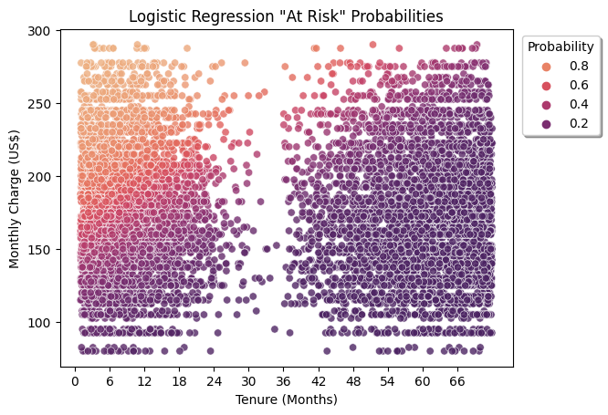

```python
sns.scatterplot(data=df,
                x='Tenure', y='MonthlyCharge',
                hue='atRisk_prob', alpha = 0.8,
                palette='flare_r')
plt.legend(bbox_to_anchor=(1.206, 1),
           loc='upper right',
           reverse=True,
           title="Probability",
           shadow=True)
plt.xlabel("Tenure (Months)")
plt.ylabel("Monthly Charge (US$)")
plt.xticks(range(0, 72, 6))
plt.title(f'Logistic Regression "At Risk" Probabilities')
plt.show()
```

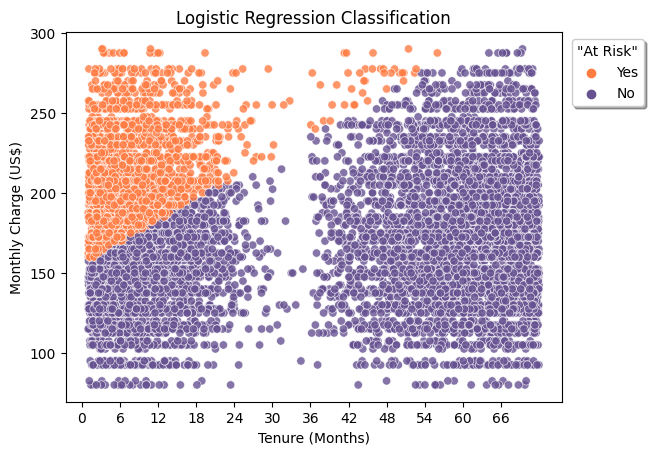

```python
my_palette_r = sns.color_palette(['#ff7c43', '#665191'])
sns.scatterplot(data=df,
                x='Tenure', y='MonthlyCharge',
                hue='atRisk', alpha = 0.8,
                palette=my_palette_r)
plt.legend(bbox_to_anchor=(1.18, 1),
           loc='upper right',
           title=f'"At Risk"',
           shadow=True)
plt.xlabel("Tenure (Months)")
plt.ylabel("Monthly Charge (US$)")
plt.xticks(range(0, 72, 6))
plt.title("Logistic Regression Classification")
plt.show()
```

```python
df_atRisk = df.copy().loc[df['atRisk']=='Yes', :]
df_atRisk_quant = df_atRisk.select_dtypes(include=('float64', 'int64'))
df_atRisk_quant = df_atRisk_quant.loc[:, ~df_atRisk_quant.columns.isin(['MonthlyCharge', 'Tenure', 'atRisk_prob'])]
df_atRisk_cat = df_atRisk.select_dtypes(include='object')
df_atRisk_cat = df_atRisk_cat.loc[:, ~df_atRisk_cat.columns.isin(['Churn', 'atRisk'])]

print(df_atRisk.info())
df_atRisk
```

```
<class 'pandas.core.frame.DataFrame'>
Int64Index: 2192 entries, 0 to 9949
Data columns (total 32 columns):
 #   Column                Non-Null Count  Dtype
---  ------                --------------  -----
 0   State                 2192 non-null   object
 1   Area                  2192 non-null   object
 2   Children              2192 non-null   int64
 3   Age                   2192 non-null   int64
 4   Income                2192 non-null   float64
 5   Marital               2192 non-null   object
 6   Gender                2192 non-null   object
 7   Churn                 2192 non-null   object
 8   Outage_sec_perweek    2192 non-null   float64
 9   Email                 2192 non-null   int64
```

[output cut: 25 more lines]

|  | State | Area | Children | Age | Income | Marital | Gender | Churn | Outage_sec_perweek | Email | Contacts | Yearly_equip_failure | Techie | Contract | Port_modem | Tablet | InternetService | Phone | Multiple | OnlineSecurity | OnlineBackup | DeviceProtection | TechSupport | StreamingTV | StreamingMovies | PaperlessBilling | PaymentMethod | Tenure | MonthlyCharge | … |
| --- | --- | --- | --- | --- | --- | --- | --- | --- | --- | --- | --- | --- | --- | --- | --- | --- | --- | --- | --- | --- | --- | --- | --- | --- | --- | --- | --- | --- | --- | --- |
| 0 | AK | Urban | 0 | 68 | 28561.99 | Widowed | Male | No | 7.978323 | 10 | 0 | 1 | No | One year | Yes | Yes | Fiber Optic | Yes | No | Yes | Yes | No | No | No | Yes | Yes | Credit Card (automatic) | 6.795513 | 172.455519 | … |
| 1 | MI | Urban | 1 | 27 | 21704.77 | Married | Female | Yes | 11.699080 | 12 | 0 | 1 | Yes | Month-to-month | No | Yes | Fiber Optic | Yes | Yes | Yes | No | No | No | Yes | Yes | Yes | Bank Transfer(automatic) | 1.156681 | 242.632554 | … |
| 5 | GA | Urban | 3 | 83 | 22660.20 | Never Married | Female | No | 8.420993 | 15 | 3 | 1 | No | One year | Yes | No | None | Yes | Yes | Yes | Yes | Yes | No | No | Yes | No | Electronic Check | 7.000994 | 185.007692 | … |
| 6 | TN | Suburban | 0 | 79 | 11467.50 | Widowed | Male | Yes | 11.182725 | 10 | 0 | 1 | Yes | Month-to-month | No | No | DSL | Yes | No | No | No | No | Yes | Yes | Yes | No | Electronic Check | 13.236774 | 200.118516 | … |
| 16 | CA | Urban | 0 | 63 | 31659.30 | Married | Female | Yes | 13.522847 | 13 | 1 | 0 | No | Month-to-month | Yes | No | DSL | Yes | Yes | No | Yes | Yes | No | No | Yes | Yes | Bank Transfer(automatic) | 15.782150 | 194.966286 | … |
| ... | ... | ... | ... | ... | ... | ... | ... | ... | ... | ... | ... | ... | ... | ... | ... | ... | ... | ... | ... | ... | ... | ... | ... | ... | ... | ... | ... | ... | ... | … |
| 9367 | PA | Rural | 4 | 27 | 10046.34 | Never Married | Female | No | 4.796609 | 10 | 0 | 0 | No | One year | No | No | None | Yes | Yes | Yes | Yes | No | Yes | Yes | Yes | Yes | Credit Card (automatic) | 38.073350 | 245.161200 | … |
| 9378 | CO | Urban | 2 | 50 | 72830.82 | Divorced | Male | Yes | 5.748230 | 14 | 0 | 0 | No | Month-to-month | No | Yes | DSL | Yes | Yes | Yes | Yes | No | No | Yes | Yes | No | Electronic Check | 39.110750 | 245.128300 | … |
| 9440 | KY | Urban | 0 | 49 | 73198.38 | Widowed | Male | Yes | 11.983580 | 13 | 0 | 1 | No | Month-to-month | Yes | No | Fiber Optic | No | Yes | Yes | Yes | No | No | Yes | Yes | No | Credit Card (automatic) | 42.478360 | 265.128300 | … |
| 9734 | WV | Urban | 1 | 35 | 6651.76 | Widowed | Male | Yes | 7.773419 | 12 | 0 | 1 | No | Two Year | Yes | Yes | DSL | Yes | Yes | Yes | Yes | Yes | Yes | Yes | Yes | Yes | Bank Transfer(automatic) | 44.423720 | 270.160400 | … |
| 9949 | WI | Urban | 4 | 43 | 68457.74 | Divorced | Female | No | 5.233119 | 12 | 1 | 1 | No | Two Year | Yes | No | Fiber Optic | Yes | Yes | Yes | Yes | No | Yes | Yes | Yes | Yes | Mailed Check | 52.626680 | 277.637500 | … |

2192 rows × 32 columns

Now that I have the "At Risk" subset of my data, I needed to find which variables were significantly different betweent the customers that actually terminated their services, and those that did not, but were predicted to have done so. This analysis flips the first on its head by making churn the independent variable instead of the dependent variable. As such, each variable will be need to be tested individually using one of two tests:

1. Mann-Whitney U test for the quantitative variables
2. Chi square test for the categorical variables

The reson I chose a Mann-Whitney U test over a traditional two-sample t-test is because many of my data are not normally distributed and some of them are ordinally measured. This can negatively impact a t-test, but a non-parametric approach remains reliable.

- Yearly equipment failure
- Bandwidth (GB/Year)
- Techie
- Contract
- Internet service
- Online security
- Online sackup
- Streaming TV
- Streaming movies
- Payment method

In order to more fully understand how these variables interact with churn, I uploaded the dataframe to tableau and created the following dashboard.

```python
p_values_quant = []
for col in df_atRisk_quant.columns:
    yes = df_atRisk.loc[df_atRisk['Churn']=='Yes', col]
    no = df_atRisk.loc[df_atRisk['Churn']=='No', col]
    p_value = stats.mannwhitneyu(yes, no).pvalue
    p_values_quant.append(p_value)
df_quant_p = pd.DataFrame([p_values_quant], columns=df_atRisk_quant.columns)
```

```python
p_values_cat = []
for col in df_atRisk_cat.columns:
    contingency_table = pd.crosstab(df_atRisk['Churn'], df_atRisk[col])
    p_value = stats.chi2_contingency(contingency_table)[1]
    p_values_cat.append(p_value)
df_cat_p = pd.DataFrame([p_values_cat], columns=df_atRisk_cat.columns)
```

```python
sig_p = pd.concat([df_quant_p.loc[:, df_quant_p.iloc[0] <= 0.05],
                                        df_cat_p.loc[:, df_cat_p.iloc[0] <= 0.05]])
sig_var = sig_p.columns.tolist()

sig_var
```

```
['Yearly_equip_failure',
 'Bandwidth_GB_Year',
 'Techie',
 'Contract',
 'InternetService',
 'OnlineSecurity',
 'OnlineBackup',
 'StreamingTV',
 'StreamingMovies',
 'PaymentMethod']
```

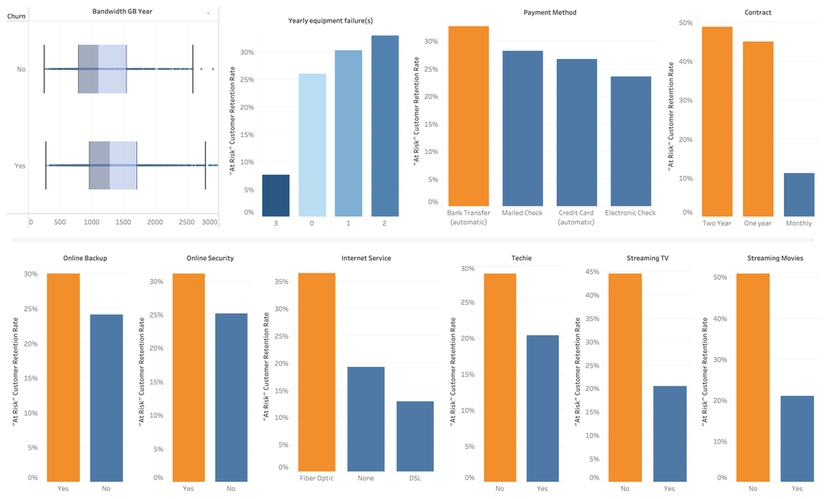

```python
#df_atRisk.to_csv('df_atRisk.csv', index=False)
#df_atRisk.loc[:, df_atRisk.columns.isin(['Bandwidth_GB_Year', 'Churn'])].to_csv('Bandwidth.csv', index=False)
display.Image('Sig_var_charts.png')
```

The Y-axis shows the retention rate as a percent of "at risk" customers; the higher the percent, the greater the retention rate. The following correlations have a positive relationship with churn:

- Bandwidth usage (GB/year)
- 3+ yearly equipment failures
- Streaming TV services
- Streaming movie services
- Someone considering themselves a "techie"

The following have a negative relationship with churn:

- Automatic bank trasnfers as payment method
- Yearly contracts
- Online backup
- Online security add-on
- Fiber optic internet

The bonferroni correction removes the following variables from the list of significance:

- Yearly equipment failure
- Payment method
- Online backup
- Online security add-on

```python
sig_p_bonferroni = pd.concat([df_quant_p.loc[:, df_quant_p.iloc[0] <= 0.05/30],
                                        df_cat_p.loc[:, df_cat_p.iloc[0] <= 0.05/30]])
sig_var_bonferroni = sig_p_bonferroni.columns.tolist()

sig_var_bonferroni
```

```
['Bandwidth_GB_Year',
 'Techie',
 'Contract',
 'InternetService',
 'StreamingTV',
 'StreamingMovies']
```

## Conclusion

The variables with a positive correlation to churn and the variables with a negative correlation to churn tell the same story: "At risk" customers who bundle their telecommunications services in yearly contracts and pay with automatic bank transfers are correlated with higher retention rates. Additionally, bundling streaming services for TV shows and movies were correlated with lower retention rates.

While the streaming services seems a little odd, everything else seems to be reasonable. Yearly contracts deter customers from terminating their services too quickly, lowering the churn rate. Automatic bank transfers make paying bills easier, making it a better and smoother experience for the customer. Additionally, the more services a customer receives from the telecommunications company, such as online security, backup, and fiber optic internet, the more justified a higher monthly charge will seem to them. Lastly, customers who consider themselves techies versus those who do not probably have a large gap in technical knoledge. It may be an easier decision for a 24 year old adult to change their telecommunications provider than for an 86 year old senior citizen.

## Recommended Course of Action:

1. Start a promotional campaign that bundles multiple services for those starting a yearly contract.
2. Offer a one time incentive for customers to set up an automatic bank transfer.
3. Try reducing streaming service packages for a period of time to see if retention rates change for at risk groups and not at risk groups alike.
4. Workshop some ideas for "easy set up" and "easy use" telecommunications services to attract non-techie customers.

As with any analysis rooted in correlation, correlation is not causation. These are ideas that may prove beneficial to the business, but continue to moniture churn rates throughout any of these courses of action to ensure that they are having a positive effect.

## Further Analysis Ideas:

During my analysis, there were plenty of features in the data that I would have loved to explore, but either did not have the time, or it was not directly applicable to this project. I would like to present one of those here that might be useful at a later time. While charting churn as a function of monthly charge and tenure, I noticed that there is a gap in tenure from approximately 24 to 36 months.